# SD_02_EMT_NUM_HIST_STR

Number of conservation easements on a certified historic structure · Number report

## Overview

**Description**

Number of easements on a certified historic structure included in (a)

**Table**

`SD-P02-T00-CONSERV-EASEMENTS` (one)

**Location code**

`SCHED-D-PART-02-LINE-02c`

**Family**

`SCHED-D-PART-02-LINE-02c`

**Data type**

numeric (xsd: , IntegerNNType)

**Scope**

PC

**Status**

unreviewed

3

xpaths mapped (2 observed)

8,284

filings with a value

2009–2024

tax years observed

1

open flags (0 errors)

## Flags

| Severity | Flag | Xpath | Detail |
| --- | --- | --- | --- |
| ⓘ info | `UNOBSERVED` | IRS990ScheduleD/Form990ScheduleDPartII/NmbrHistStructEasements | never observed in TY2009-2024 filings |

## Xpaths

All mapped xpaths (under /Return/ReturnData or /Return/ReturnHeader), oldest first. Charts label each series by its xpath.

| Xpath | Form | Chart label | First year | Last year | Versions | Filings | Repeats in |
| --- | --- | --- | --- | --- | --- | --- | --- |
| IRS990ScheduleD/NmbrHistStructEasements | Sched D | same | 2009 | 2012 | 15 | 1,393 | 0.0% |
| IRS990ScheduleD/HistoricStructureEasementsCnt | Sched D | same | 2013 | 2024 | 37 | 6,891 | 0.0% |
| IRS990ScheduleD/Form990ScheduleDPartII/NmbrHistStructEasements | Sched D | …0ScheduleD/Form990ScheduleDPartII/NmbrHistStructEasements |  |  |  | 0 |  |

## Coverage

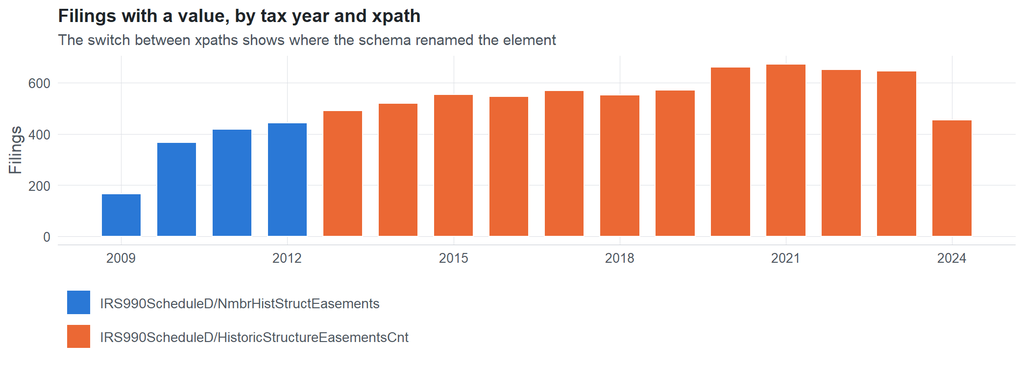

**Table view**

Table view: filings by tax year and series

| Tax year | IRS990ScheduleD/NmbrHistStructEasements | IRS990ScheduleD/HistoricStructureEasementsCnt |
| --- | --- | --- |
| 2009 | 166 | 0 |
| 2010 | 366 | 0 |
| 2011 | 418 | 0 |
| 2012 | 443 | 0 |
| 2013 | 0 | 491 |
| 2014 | 0 | 520 |
| 2015 | 0 | 555 |
| 2016 | 0 | 547 |
| 2017 | 0 | 569 |
| 2018 | 0 | 552 |
| 2019 | 0 | 572 |
| 2020 | 0 | 662 |
| 2021 | 0 | 672 |
| 2022 | 0 | 652 |
| 2023 | 0 | 645 |
| 2024 | 0 | 454 |

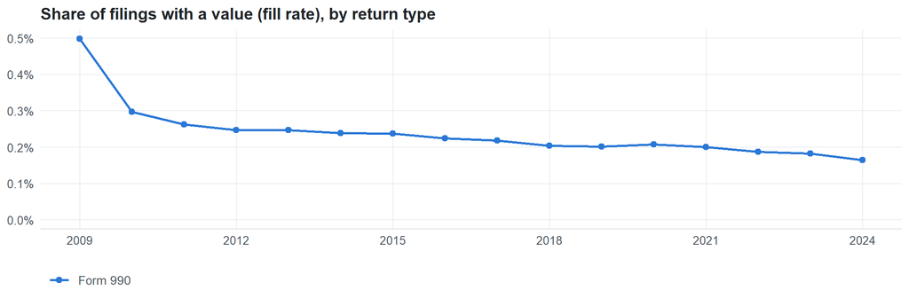

**Table view**

Table view: fill rate

| Tax year | Return type | Filings | All filings | Fill rate |
| --- | --- | --- | --- | --- |
| 2009 | Form 990 | 166 | 33,311 | 0.50% |
| 2010 | Form 990 | 366 | 123,025 | 0.30% |
| 2011 | Form 990 | 418 | 159,504 | 0.26% |
| 2012 | Form 990 | 443 | 179,688 | 0.25% |
| 2013 | Form 990 | 491 | 198,855 | 0.25% |
| 2014 | Form 990 | 520 | 218,619 | 0.24% |
| 2015 | Form 990 | 555 | 233,519 | 0.24% |
| 2016 | Form 990 | 547 | 243,903 | 0.22% |
| 2017 | Form 990 | 569 | 261,612 | 0.22% |
| 2018 | Form 990 | 552 | 271,442 | 0.20% |
| 2019 | Form 990 | 572 | 283,694 | 0.20% |
| 2020 | Form 990 | 662 | 320,342 | 0.21% |
| 2021 | Form 990 | 672 | 336,480 | 0.20% |
| 2022 | Form 990 | 652 | 349,055 | 0.19% |
| 2023 | Form 990 | 645 | 354,768 | 0.18% |
| 2024 | Form 990 | 454 | 277,298 | 0.16% |

## Values

| Result | Check | Detail |
| --- | --- | --- |
| ✓ pass | Values parse as numbers | 100.0% of values are numeric |
| ✓ pass | Pooled xpaths are on the same scale (same return type) | largest ratio of medians between xpaths: 1.0x |
| ⚠ fail | One scale across xpaths (fraction vs percent) | IRS990ScheduleD/HistoricStructureEasementsCnt: large count or amount; IRS990ScheduleD/NmbrHistStructEasements: percent or small count |

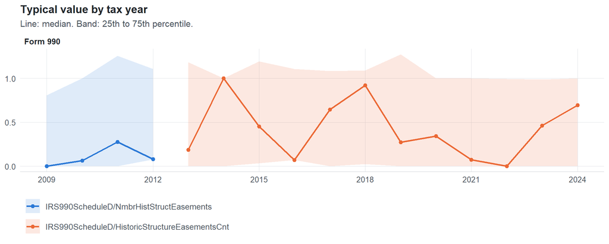

**Table view**

Table view: quartiles by tax year

| Series | Return | Tax year | Filings | P25 | Median | P75 |
| --- | --- | --- | --- | --- | --- | --- |
| IRS990ScheduleD/NmbrHistStructEasements | 990 | 2009 | 166 | 0 | 0 | 0.81 |
| IRS990ScheduleD/NmbrHistStructEasements | 990 | 2010 | 366 | 0 | 0.06 | 1 |
| IRS990ScheduleD/NmbrHistStructEasements | 990 | 2011 | 418 | 0 | 0.28 | 1.26 |
| IRS990ScheduleD/NmbrHistStructEasements | 990 | 2012 | 443 | 0.08 | 0.08 | 1.11 |
| IRS990ScheduleD/HistoricStructureEasementsCnt | 990 | 2013 | 491 | 0 | 0.19 | 1.19 |
| IRS990ScheduleD/HistoricStructureEasementsCnt | 990 | 2014 | 520 | 0 | 1 | 1 |
| IRS990ScheduleD/HistoricStructureEasementsCnt | 990 | 2015 | 555 | 0.03 | 0.45 | 1.19 |
| IRS990ScheduleD/HistoricStructureEasementsCnt | 990 | 2016 | 547 | 0.07 | 0.07 | 1.11 |
| IRS990ScheduleD/HistoricStructureEasementsCnt | 990 | 2017 | 569 | 0 | 0.65 | 1.08 |
| IRS990ScheduleD/HistoricStructureEasementsCnt | 990 | 2018 | 552 | 0.02 | 0.92 | 1.09 |
| IRS990ScheduleD/HistoricStructureEasementsCnt | 990 | 2019 | 572 | 0 | 0.27 | 1.27 |
| IRS990ScheduleD/HistoricStructureEasementsCnt | 990 | 2020 | 662 | 0 | 0.34 | 1 |
| IRS990ScheduleD/HistoricStructureEasementsCnt | 990 | 2021 | 672 | 0 | 0.07 | 1 |
| IRS990ScheduleD/HistoricStructureEasementsCnt | 990 | 2022 | 652 | 0 | 0 | 0.99 |
| IRS990ScheduleD/HistoricStructureEasementsCnt | 990 | 2023 | 645 | 0 | 0.46 | 0.99 |
| IRS990ScheduleD/HistoricStructureEasementsCnt | 990 | 2024 | 454 | 0 | 0.69 | 1 |

Summary by xpath and return type (all years)

| Series | Return | Filings | % numeric | % zero | % negative | Median (typical year) | P99 (typical year) |
| --- | --- | --- | --- | --- | --- | --- | --- |
| IRS990ScheduleD/NmbrHistStructEasements | 990 | 1,393 | 100 | 55.78 | 0 | 0 | 38 |
| IRS990ScheduleD/HistoricStructureEasementsCnt | 990 | 6,891 | 100 | 50.52 | 0 | 0 | 115 |

Scale of each xpath

| Series | P99 (typical year) | Implied scale |
| --- | --- | --- |
| IRS990ScheduleD/HistoricStructureEasementsCnt | 115 | large count or amount |
| IRS990ScheduleD/NmbrHistStructEasements | 38 | percent or small count |

## Examples

| Tax year | Return | Xpath | Organization | Value | Source |
| --- | --- | --- | --- | --- | --- |
| 2024 | 990 | IRS990ScheduleD/HistoricStructureEasementsCnt | Flying Yankee Restoration Group Inc | 1 | [XML](https://gt990datalake-rawdata.s3.amazonaws.com/EfileData/XmlFiles/202510669349300306_public.xml) |
| 2023 | 990 | IRS990ScheduleD/HistoricStructureEasementsCnt | THE HABONIM CAMP ASSOCIATION COMPANY INCORPORATED | 0 | [XML](https://gt990datalake-rawdata.s3.amazonaws.com/EfileData/XmlFiles/202440829349300774_public.xml) |
| 2022 | 990 | IRS990ScheduleD/HistoricStructureEasementsCnt | LAKE CHAMPLAIN LAND TRUST INC | 0 | [XML](https://gt990datalake-rawdata.s3.amazonaws.com/EfileData/XmlFiles/202313199349302016_public.xml) |
| 2021 | 990 | IRS990ScheduleD/HistoricStructureEasementsCnt | WILDACRES RETREAT | 0 | [XML](https://gt990datalake-rawdata.s3.amazonaws.com/EfileData/XmlFiles/202223159349301142_public.xml) |
| 2020 | 990 | IRS990ScheduleD/HistoricStructureEasementsCnt | WACCAMAW COMMUNITY FOUNDATION | 0 | [XML](https://gt990datalake-rawdata.s3.amazonaws.com/EfileData/XmlFiles/202112429349300101_public.xml) |
| 2019 | 990 | IRS990ScheduleD/HistoricStructureEasementsCnt | OCONEE RIVER LAND TRUST | 0 | [XML](https://gt990datalake-rawdata.s3.amazonaws.com/EfileData/XmlFiles/202032239349300433_public.xml) |
| 2018 | 990 | IRS990ScheduleD/HistoricStructureEasementsCnt | COMMUNITY HOSPITAL OF THE MONTEREY | 0 | [XML](https://gt990datalake-rawdata.s3.amazonaws.com/EfileData/XmlFiles/201943189349314499_public.xml) |
| 2017 | 990 | IRS990ScheduleD/HistoricStructureEasementsCnt | ASHLAND UNIVERSITY | 0 | [XML](https://gt990datalake-rawdata.s3.amazonaws.com/EfileData/XmlFiles/201921059349300917_public.xml) |
| 2016 | 990 | IRS990ScheduleD/HistoricStructureEasementsCnt | SHANDS JACKSONVILLE MEDICAL CENTER INC | 0 | [XML](https://gt990datalake-rawdata.s3.amazonaws.com/EfileData/XmlFiles/201811359349300021_public.xml) |
| 2015 | 990 | IRS990ScheduleD/HistoricStructureEasementsCnt | PHILIPS TOWER DECATUR INC | 0 | [XML](https://gt990datalake-rawdata.s3.amazonaws.com/EfileData/XmlFiles/201632239349301903_public.xml) |
| 2014 | 990 | IRS990ScheduleD/HistoricStructureEasementsCnt | IUL SMITHVILLE SCHOOL MUSEUM & EDUC | 1 | [XML](https://gt990datalake-rawdata.s3.amazonaws.com/EfileData/XmlFiles/201531249349301378_public.xml) |
| 2013 | 990 | IRS990ScheduleD/HistoricStructureEasementsCnt | PLANO LAND TRUST CORPORATION | 0 | [XML](https://gt990datalake-rawdata.s3.amazonaws.com/EfileData/XmlFiles/201403189349302340_public.xml) |

## Reviewer checklist

- The definition matches the form line and instructions for every xpath’s schema years.
- Every xpath pooled here measures the same thing on the 990 and 990-EZ (close enough for analysis).
- The coverage chart has no unexplained gaps or jumps between tax years.
- Each open flag is fixed, or accepted with a note in validation_log.csv.
- Counts are whole numbers and plausible (e.g. employees, volunteers, voting members).
- Ratios and percentages use one scale (0-1 or 0-100) across all xpaths and years.
- Units match the form line (hours per week, number of states, percent of support).

Record the review as a row in `inst/extdata/src/validation_log.csv` (variable_name, reviewer, date, status, note). Evidence built 2026-09-23 17:09:04 MST from the ef2 DuckDB builds (tax years 2009–2024).